# MB5370: Techniques in Marine Science 1

# Module 2 - Workshop 01. Foundations of Data Science

House Keeping

```r
objects()
```

```
## character(0)
```

Purge global environment

```r
rm(list = ls())
```

Confirm that global session memory is now completely vacant

```r
objects()
```

```
## character(0)
```

Install here package

```r
# install.packages("here")
```

Load here package

```r
library(here)
library(tidyverse)
library(readxl)
```

Practice Import A: Loading a standard comma-separated plain text file

```r
benthic_cover <- read_csv("data/reef_cover_log.csv")
```

Practice Import B: Parsing a tab-separated telemetry instrument array string

```r
acoustic_stream <- read_tsv("data/acoustic_telemetry_stream.txt")
```

Practice Import C: Targeting a specific sheet in a multi-tab Excel spreadsheet

```r
fisheries_annual <- read_excel("data/fish_catch_data.xlsx", sheet = "Commercial_2026")
```

Read in mangrove_data

```r
mangrove_data <- read_csv("data/mangrove_survey_raw.csv")
```

```r
mangrove_data <- read_csv("data/mangrove_survey_raw.csv",
  skip = 5,    # Skip the first 5 lines of field notes
  na = c(".", "NA", "9999", "ND", "blank"))  # Convert known text alts to true NA
```

Force a modern tibble to degrade into a legacy base R data frame structure

```r
benthic_cover_df <- as.data.frame(benthic_cover)
```

Print the old-style dataframe structure to view

```r
print(benthic_cover_df)
```

```
##        site_id transect_no       date depth_m hard_coral_pct macroalgae_pct
## 1    Nelly_Bay           1 2026-05-10     4.5           45.2           12.1
## 2    Nelly_Bay           2 2026-05-10     5.1           38.5           15.4
## 3 Geoffrey_Bay           1 2026-05-11     3.8           52.1            8.3
## 4 Geoffrey_Bay           2 2026-05-11     4.2           48.9           10.2
## 5 Florence_Bay           1 2026-05-12     6.0           61.3            5.1
## 6 Florence_Bay           2 2026-05-12     5.8           58.7            6.4
##   bare_substrate_pct
## 1               42.7
## 2               46.1
## 3               39.6
## 4               40.9
## 5               33.6
## 6               34.9
```

Compare with tibble alternative

```r
print(benthic_cover)
```

```
## # A tibble: 6 × 7
##   site_id      transect_no date       depth_m hard_coral_pct macroalgae_pct
##   <chr>              <dbl> <date>       <dbl>          <dbl>          <dbl>
## 1 Nelly_Bay              1 2026-05-10     4.5           45.2           12.1
## 2 Nelly_Bay              2 2026-05-10     5.1           38.5           15.4
## 3 Geoffrey_Bay           1 2026-05-11     3.8           52.1            8.3
## 4 Geoffrey_Bay           2 2026-05-11     4.2           48.9           10.2
## 5 Florence_Bay           1 2026-05-12     6             61.3            5.1
## 6 Florence_Bay           2 2026-05-12     5.8           58.7            6.4
## # ℹ 1 more variable: bare_substrate_pct <dbl>
```

Install the data package

```r
# install.packages("palmerpenguins")
```

Load the package data into active memory

```r
library(palmerpenguins)
data("penguins")
```

Examine the structure of the dataset - always do this when loading a new dataset!

```r
glimpse(penguins) # tidyverse version (from dplyr package)
```

```
## Rows: 344
## Columns: 8
## $ species           <fct> Adelie, Adelie, Adelie, Adelie, Adelie, Adelie, Adel…
## $ island            <fct> Torgersen, Torgersen, Torgersen, Torgersen, Torgerse…
## $ bill_length_mm    <dbl> 39.1, 39.5, 40.3, NA, 36.7, 39.3, 38.9, 39.2, 34.1, …
## $ bill_depth_mm     <dbl> 18.7, 17.4, 18.0, NA, 19.3, 20.6, 17.8, 19.6, 18.1, …
## $ flipper_length_mm <int> 181, 186, 195, NA, 193, 190, 181, 195, 193, 190, 186…
## $ body_mass_g       <int> 3750, 3800, 3250, NA, 3450, 3650, 3625, 4675, 3475, …
## $ sex               <fct> male, female, female, NA, female, male, female, male…
## $ year              <int> 2007, 2007, 2007, 2007, 2007, 2007, 2007, 2007, 2007…
```

```r
str(penguins) # base R version
```

```
## tibble [344 × 8] (S3: tbl_df/tbl/data.frame)
##  $ species          : Factor w/ 3 levels "Adelie","Chinstrap",..: 1 1 1 1 1 1 1 1 1 1 ...
##  $ island           : Factor w/ 3 levels "Biscoe","Dream",..: 3 3 3 3 3 3 3 3 3 3 ...
##  $ bill_length_mm   : num [1:344] 39.1 39.5 40.3 NA 36.7 39.3 38.9 39.2 34.1 42 ...
##  $ bill_depth_mm    : num [1:344] 18.7 17.4 18 NA 19.3 20.6 17.8 19.6 18.1 20.2 ...
##  $ flipper_length_mm: int [1:344] 181 186 195 NA 193 190 181 195 193 190 ...
##  $ body_mass_g      : int [1:344] 3750 3800 3250 NA 3450 3650 3625 4675 3475 4250 ...
##  $ sex              : Factor w/ 2 levels "female","male": 2 1 1 NA 1 2 1 2 NA NA ...
##  $ year             : int [1:344] 2007 2007 2007 2007 2007 2007 2007 2007 2007 2007 ...
```

Generate an exploratory summary matrix

```r
summary(penguins)
```

```
##       species          island    bill_length_mm  bill_depth_mm
##  Adelie   :152   Biscoe   :168   Min.   :32.10   Min.   :13.10
##  Chinstrap: 68   Dream    :124   1st Qu.:39.23   1st Qu.:15.60
##  Gentoo   :124   Torgersen: 52   Median :44.45   Median :17.30
##                                  Mean   :43.92   Mean   :17.15
##                                  3rd Qu.:48.50   3rd Qu.:18.70
##                                  Max.   :59.60   Max.   :21.50
##                                  NA's   :2       NA's   :2
##  flipper_length_mm  body_mass_g       sex           year
##  Min.   :172.0     Min.   :2700   female:165   Min.   :2007
##  1st Qu.:190.0     1st Qu.:3550   male  :168   1st Qu.:2007
##  Median :197.0     Median :4050   NA's  : 11   Median :2008
##  Mean   :200.9     Mean   :4202                Mean   :2008
##  3rd Qu.:213.0     3rd Qu.:4750                3rd Qu.:2009
##  Max.   :231.0     Max.   :6300                Max.   :2009
##  NA's   :2         NA's   :2
```

Vertically slice specific morphometric variables by explicit name

```r
morphology_metrics <- select(penguins, species, bill_length_mm, bill_depth_mm, body_mass_g)
glimpse(morphology_metrics)
```

```
## Rows: 344
## Columns: 4
## $ species        <fct> Adelie, Adelie, Adelie, Adelie, Adelie, Adelie, Adelie,…
## $ bill_length_mm <dbl> 39.1, 39.5, 40.3, NA, 36.7, 39.3, 38.9, 39.2, 34.1, 42.…
## $ bill_depth_mm  <dbl> 18.7, 17.4, 18.0, NA, 19.3, 20.6, 17.8, 19.6, 18.1, 20.…
## $ body_mass_g    <int> 3750, 3800, 3250, NA, 3450, 3650, 3625, 4675, 3475, 425…
```

Retain a continuous block of attributes using the colon operator

```r
spatial_block <- select(penguins, species:island)
```

Discard logistics tracking attributes while preserving everything else using the minus sign

```r
clean_scientific_fields <- select(penguins, -year)
```

Isolate observations belonging to a single categorical target group

```r
adelie_cohort <- filter(penguins, species == "Adelie")
```

#### Sift out individuals using continuous numerical boundary thresholds

Preserves only large penguins whose mass exceeds 4500 grams

```r
heavy_penguins <- filter(penguins, body_mass_g > 4500)
```

#### Combine multiple conditional parameters across separate attributes

Preserves records matching Gentoo penguins sampled explicitly on Biscoe Island

```r
biscoe_gentoo <- filter(penguins, species == "Gentoo" & island == "Biscoe")
```

Sift records matching multiple targeting flags within an explicit set

```r
sub_islands <- filter(penguins, island %in% c("Dream", "Torgersen"))
```

Sort penguins by ascending body mass (Default setting: Smallest mass first)

```r
lightest_first <- arrange(penguins, body_mass_g)
```

Sort penguins in descending sequence using the desc() layout wrapper

```r
heaviest_first <- arrange(penguins, desc(body_mass_g))
```

Execute nested sorting criteria: Group by species, then sort by descending bill length

```r
stratified_morphology <- arrange(penguins, species, desc(bill_length_mm))
```

Pipe: best way

```r
penguins_final <- penguins |>
  mutate(bill_ratio = bill_length_mm / bill_depth_mm) |>
  filter(species == "Adelie")
```

Calculate a new morphological ratio in our environment

```r
penguin_ratios <- penguins  |>
  mutate(body_mass_kg = body_mass_g / 1000,   # Convert grams to kilograms
         bill_ratio = bill_length_mm / bill_depth_mm  # Bill ratio
  )
```

View your newly engineered variables appended to the far-right columns

```r
glimpse(penguin_ratios)
```

```
## Rows: 344
## Columns: 10
## $ species           <fct> Adelie, Adelie, Adelie, Adelie, Adelie, Adelie, Adel…
## $ island            <fct> Torgersen, Torgersen, Torgersen, Torgersen, Torgerse…
## $ bill_length_mm    <dbl> 39.1, 39.5, 40.3, NA, 36.7, 39.3, 38.9, 39.2, 34.1, …
## $ bill_depth_mm     <dbl> 18.7, 17.4, 18.0, NA, 19.3, 20.6, 17.8, 19.6, 18.1, …
## $ flipper_length_mm <int> 181, 186, 195, NA, 193, 190, 181, 195, 193, 190, 186…
## $ body_mass_g       <int> 3750, 3800, 3250, NA, 3450, 3650, 3625, 4675, 3475, …
## $ sex               <fct> male, female, female, NA, female, male, female, male…
## $ year              <int> 2007, 2007, 2007, 2007, 2007, 2007, 2007, 2007, 2007…
## $ body_mass_kg      <dbl> 3.750, 3.800, 3.250, NA, 3.450, 3.650, 3.625, 4.675,…
## $ bill_ratio        <dbl> 2.090909, 2.270115, 2.238889, NA, 1.901554, 1.907767…
```

Grouping our active memory penguins by species

```r
grouped_penguins <- group_by(penguins, species)
```

Notice that the table looks identical, but metadata notes ‘Groups: species [3]’

```r
print(grouped_penguins)
```

```
## # A tibble: 344 × 8
## # Groups:   species [3]
##    species island    bill_length_mm bill_depth_mm flipper_length_mm body_mass_g
##    <fct>   <fct>              <dbl>         <dbl>             <int>       <int>
##  1 Adelie  Torgersen           39.1          18.7               181        3750
##  2 Adelie  Torgersen           39.5          17.4               186        3800
##  3 Adelie  Torgersen           40.3          18                 195        3250
##  4 Adelie  Torgersen           NA            NA                  NA          NA
##  5 Adelie  Torgersen           36.7          19.3               193        3450
##  6 Adelie  Torgersen           39.3          20.6               190        3650
##  7 Adelie  Torgersen           38.9          17.8               181        3625
##  8 Adelie  Torgersen           39.2          19.6               195        4675
##  9 Adelie  Torgersen           34.1          18.1               193        3475
## 10 Adelie  Torgersen           42            20.2               190        4250
## # ℹ 334 more rows
## # ℹ 2 more variables: sex <fct>, year <int>
```

Collapsing the buckets into explicit summary metrics

```r
species_mass_summary <- summarise(grouped_penguins,
                                  mean_mass_g = mean(body_mass_g)
)

print(species_mass_summary)
```

```
## # A tibble: 3 × 2
##   species   mean_mass_g
##   <fct>           <dbl>
## 1 Adelie            NA
## 2 Chinstrap       3733.
## 3 Gentoo            NA
```

Overcoming the missing value trap using na.rm = TRUE

```r
biological_signal <- penguins %>%
  group_by(species, sex) %>%
  summarise(
    sample_size = n(),                                     # Count total individuals per category
    mean_mass_g = mean(body_mass_g, na.rm = TRUE),         # Calculate mean ignoring missing cells
    sd_mass_g   = sd(body_mass_g, na.rm = TRUE)            # Standard deviation calculation
  )

print(biological_signal)
```

```
## # A tibble: 8 × 5
## # Groups:   species [3]
##   species   sex    sample_size mean_mass_g sd_mass_g
##   <fct>     <fct>        <int>       <dbl>     <dbl>
## 1 Adelie    female          73       3369.      269.
## 2 Adelie    male            73       4043.      347.
## 3 Adelie    <NA>             6       3540       477.
## 4 Chinstrap female          34       3527.      285.
## 5 Chinstrap male            34       3939.      362.
## 6 Gentoo    female          58       4680.      282.
## 7 Gentoo    male            61       5485.      313.
## 8 Gentoo    <NA>             5       4588.      338.
```

#### Pipe directly from aggregation to plotting with error bars

Save the summary table

```r
mass_compare_plot <- penguins |>
  group_by(species, island) |>
  summarise(
    mean_mass = mean(body_mass_g, na.rm = TRUE),
    sd_mass = sd(body_mass_g, na.rm = TRUE),
    n = n(),
    .groups = "drop"
  )
```

Print the summary table

```r
print(mass_compare_plot)
```

```
## # A tibble: 5 × 5
##   species   island    mean_mass sd_mass     n
##   <fct>     <fct>         <dbl>   <dbl> <int>
## 1 Adelie    Biscoe        3710.    488.    44
## 2 Adelie    Dream         3688.    455.    56
## 3 Adelie    Torgersen     3706.    445.    52
## 4 Chinstrap Dream         3733.    384.    68
## 5 Gentoo    Biscoe        5076.    504.   124
```

Plot from the saved summary object

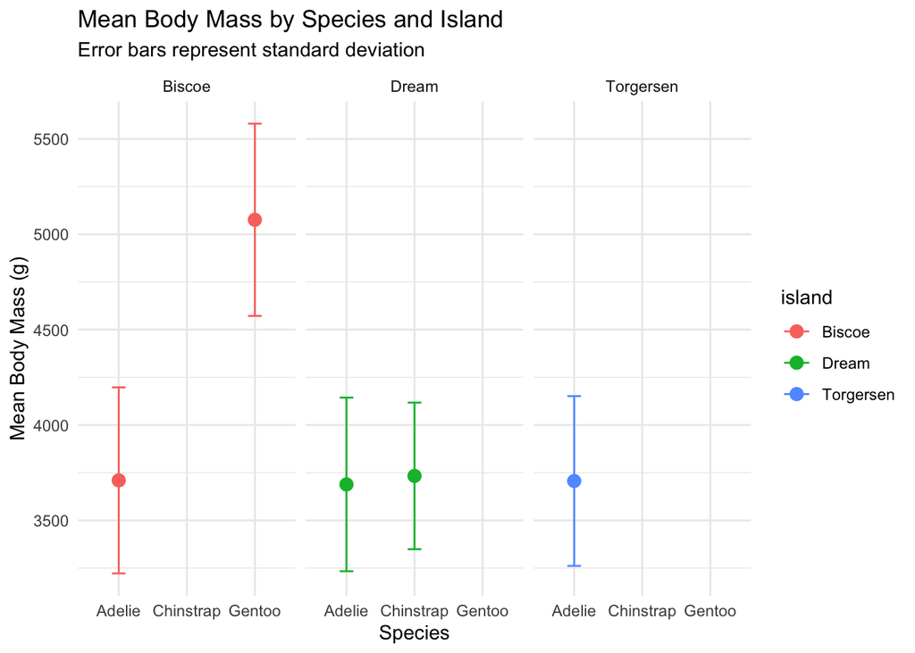

```r
ggplot(mass_compare_plot, aes(x = species, y = mean_mass, colour = island)) +
  geom_point(size = 3) +
  geom_errorbar(aes(ymin = mean_mass - sd_mass,
                    ymax = mean_mass + sd_mass),
                width = 0.2) +
  facet_wrap(~island) +
  labs(title = "Mean Body Mass by Species and Island",
       subtitle = "Error bars represent standard deviation",
       y = "Mean Body Mass (g)",
       x = "Species") +
  theme_minimal()
```

```r
mass_compare_plot
```

```
## # A tibble: 5 × 5
##   species   island    mean_mass sd_mass     n
##   <fct>     <fct>         <dbl>   <dbl> <int>
## 1 Adelie    Biscoe        3710.    488.    44
## 2 Adelie    Dream         3688.    455.    56
## 3 Adelie    Torgersen     3706.    445.    52
## 4 Chinstrap Dream         3733.    384.    68
## 5 Gentoo    Biscoe        5076.    504.   124
```

#### Change from standard deviation to standard error for mass

Save the summary table

```r
mass_compare_plot <- penguins |>
  group_by(species, island) |>
  summarise(
    mean_mass = mean(body_mass_g, na.rm = TRUE),
    se_mass   = sd(body_mass_g, na.rm = TRUE) / sqrt(n()),
    n         = n(),
    .groups   = "drop"
  )
```

Print the summary table

```r
print(mass_compare_plot)
```

```
## # A tibble: 5 × 5
##   species   island    mean_mass se_mass     n
##   <fct>     <fct>         <dbl>   <dbl> <int>
## 1 Adelie    Biscoe        3710.    73.5    44
## 2 Adelie    Dream         3688.    60.8    56
## 3 Adelie    Torgersen     3706.    61.7    52
## 4 Chinstrap Dream         3733.    46.6    68
## 5 Gentoo    Biscoe        5076.    45.3   124
```

Plot from the saved summary object

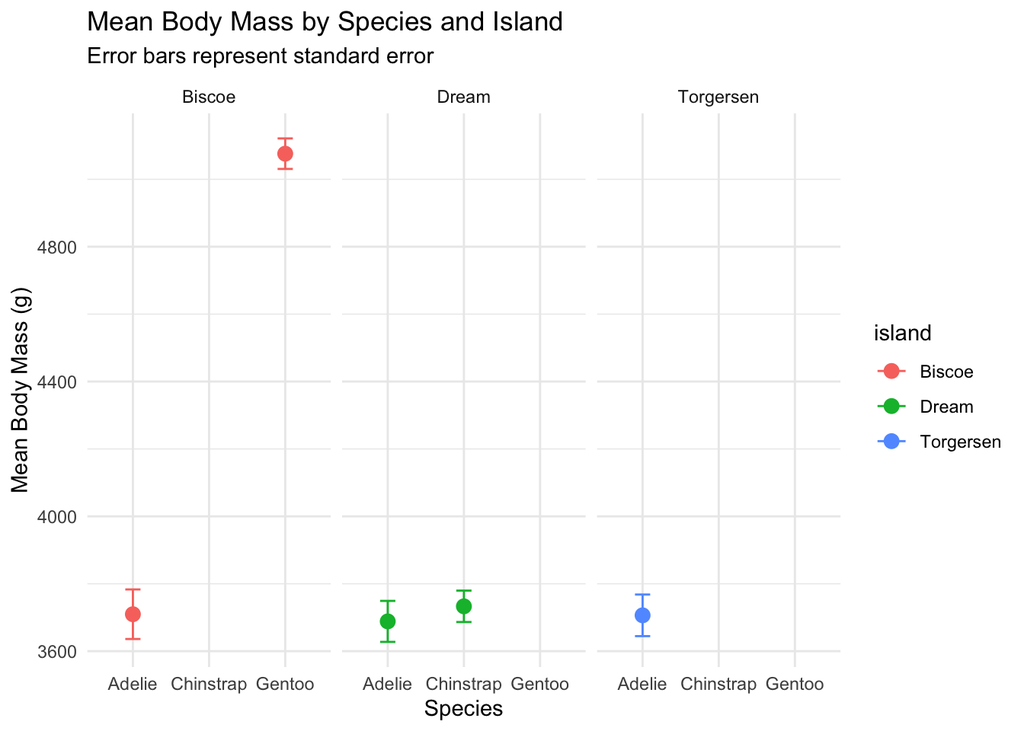

```r
ggplot(mass_compare_plot, aes(x = species, y = mean_mass, colour = island)) +
  geom_point(size = 3) +
  geom_errorbar(aes(ymin = mean_mass - se_mass,
                    ymax = mean_mass + se_mass),
                width = 0.2) +
  facet_wrap(~island) +
  labs(title    = "Mean Body Mass by Species and Island",
       subtitle = "Error bars represent standard error",
       y        = "Mean Body Mass (g)",
       x        = "Species") +
  theme_minimal()
```

```r
mass_compare_plot
```

```
## # A tibble: 5 × 5
##   species   island    mean_mass se_mass     n
##   <fct>     <fct>         <dbl>   <dbl> <int>
## 1 Adelie    Biscoe        3710.    73.5    44
## 2 Adelie    Dream         3688.    60.8    56
## 3 Adelie    Torgersen     3706.    61.7    52
## 4 Chinstrap Dream         3733.    46.6    68
## 5 Gentoo    Biscoe        5076.    45.3   124
```

#### Make plots look more presentable

Standard deviation

```r
mass_compare_plot <- penguins |>
  group_by(species, island) |>
    summarise(
      mean_mass = mean(body_mass_g, na.rm = TRUE),
      sd_mass   = sd(body_mass_g, na.rm = TRUE),
      n         = n(),
      .groups   = "drop"
      )
```

Print the summary table

```r
print(mass_compare_plot)
```

```
## # A tibble: 5 × 5
##   species   island    mean_mass sd_mass     n
##   <fct>     <fct>         <dbl>   <dbl> <int>
## 1 Adelie    Biscoe        3710.    488.    44
## 2 Adelie    Dream         3688.    455.    56
## 3 Adelie    Torgersen     3706.    445.    52
## 4 Chinstrap Dream         3733.    384.    68
## 5 Gentoo    Biscoe        5076.    504.   124
```

Plot from the saved summary object

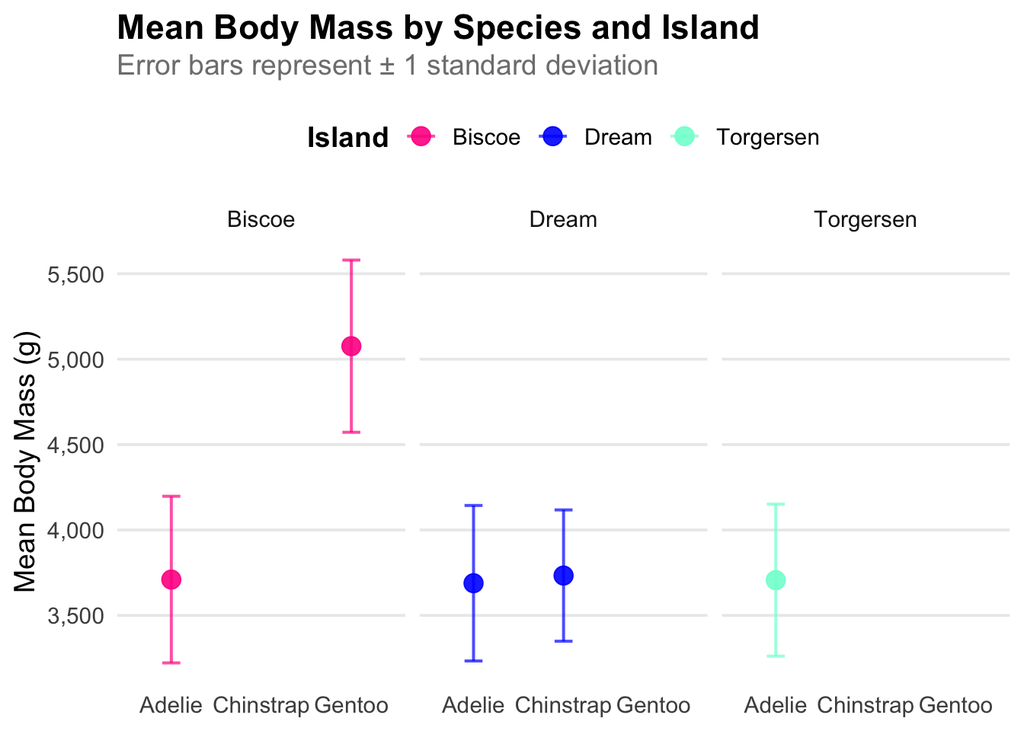

```r
ggplot(mass_compare_plot, aes(x = species, y = mean_mass, colour = island)) +
  geom_errorbar(aes(ymin = mean_mass - sd_mass,
                    ymax = mean_mass + sd_mass),
                width = 0.2, linewidth = 0.7, alpha = 0.7) +
  facet_wrap(~island) +
  geom_point(size = 4, alpha = 0.9) +
  scale_colour_manual(values = c(
    "Biscoe"    = "deeppink",
    "Dream"     = "blue",
    "Torgersen" = "aquamarine"
  )) +
  scale_y_continuous(labels = scales::comma) +
  labs(
    title    = "Mean Body Mass by Species and Island",
    subtitle = "Error bars represent ± 1 standard deviation",
    y        = "Mean Body Mass (g)",
    x        = NULL,
    colour   = "Island"
  ) +
  theme_minimal(base_size = 14) +
  theme(
    plot.title       = element_text(face = "bold", margin = margin(b = 4)),
    plot.subtitle    = element_text(colour = "grey50", margin = margin(b = 12)),
    panel.grid.major.x = element_blank(),
    panel.grid.minor   = element_blank(),
    legend.position  = "top",
    legend.title     = element_text(face = "bold"),
    axis.text        = element_text(colour = "grey30")
  )
```

```r
mass_compare_plot
```

```
## # A tibble: 5 × 5
##   species   island    mean_mass sd_mass     n
##   <fct>     <fct>         <dbl>   <dbl> <int>
## 1 Adelie    Biscoe        3710.    488.    44
## 2 Adelie    Dream         3688.    455.    56
## 3 Adelie    Torgersen     3706.    445.    52
## 4 Chinstrap Dream         3733.    384.    68
## 5 Gentoo    Biscoe        5076.    504.   124
```

Standard deviation changed to standard error

Save the summary table

```r
mass_compare_plot <- penguins |>
  group_by(species, island) |>
  summarise(
    mean_mass = mean(body_mass_g, na.rm = TRUE),
    se_mass   = sd(body_mass_g, na.rm = TRUE) / sqrt(n()),
    n         = n(),
    .groups   = "drop"
  )
```

Print the summary table

```r
print(mass_compare_plot)
```

```
## # A tibble: 5 × 5
##   species   island    mean_mass se_mass     n
##   <fct>     <fct>         <dbl>   <dbl> <int>
## 1 Adelie    Biscoe        3710.    73.5    44
## 2 Adelie    Dream         3688.    60.8    56
## 3 Adelie    Torgersen     3706.    61.7    52
## 4 Chinstrap Dream         3733.    46.6    68
## 5 Gentoo    Biscoe        5076.    45.3   124
```

Plot from the saved summary object

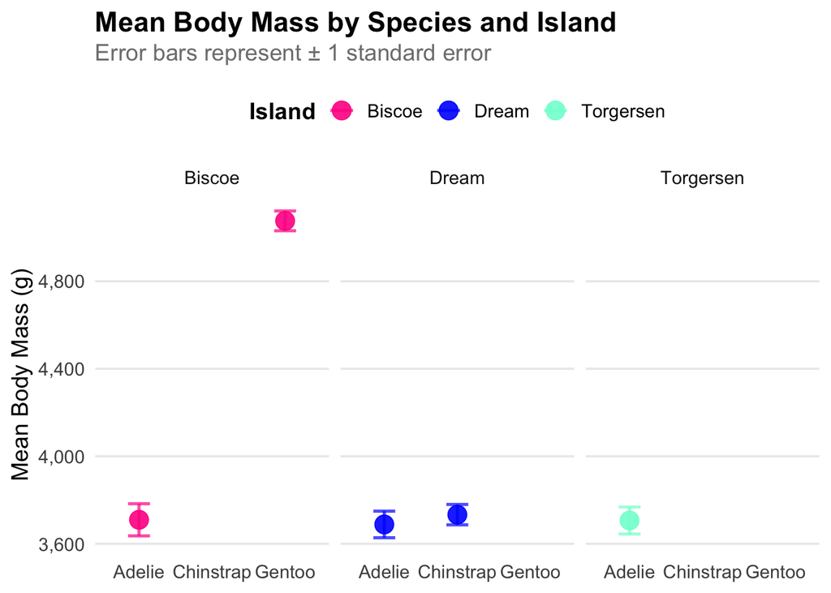

```r
ggplot(mass_compare_plot, aes(x = species, y = mean_mass, colour = island)) +
  geom_errorbar(aes(ymin = mean_mass - se_mass,
                    ymax = mean_mass + se_mass),
                width = 0.3, linewidth = 0.9, alpha = 0.7) +
  facet_wrap(~island) +
  geom_point(size = 5, alpha = 0.9) +
  scale_colour_manual(values = c(
    "Biscoe"    = "deeppink",
    "Dream"     = "blue",
    "Torgersen" = "aquamarine"
  )) +
  scale_y_continuous(labels = scales::comma) +
  labs(
    title    = "Mean Body Mass by Species and Island",
    subtitle = "Error bars represent ± 1 standard error",
    y        = "Mean Body Mass (g)",
    x        = NULL,
    colour   = "Island"
  ) +
  theme_minimal(base_size = 14) +
  theme(
    plot.title         = element_text(face = "bold", margin = margin(b = 4)),
    plot.subtitle      = element_text(colour = "grey50", margin = margin(b = 12)),
    panel.grid.major.x = element_blank(),
    panel.grid.minor   = element_blank(),
    legend.position    = "top",
    legend.title       = element_text(face = "bold"),
    axis.text          = element_text(colour = "grey30")
  )
```

```r
mass_compare_plot
```

```
## # A tibble: 5 × 5
##   species   island    mean_mass se_mass     n
##   <fct>     <fct>         <dbl>   <dbl> <int>
## 1 Adelie    Biscoe        3710.    73.5    44
## 2 Adelie    Dream         3688.    60.8    56
## 3 Adelie    Torgersen     3706.    61.7    52
## 4 Chinstrap Dream         3733.    46.6    68
## 5 Gentoo    Biscoe        5076.    45.3   124
```